# Exercise 07

Author

Sarah Lötscher

Published

October 31, 2022

# Exercise 7: playing with design/contrast matrices, UpSet plots and differential expression with count data

```r
#Packages
library(limma)
library(edgeR)
library(affy)
library(UpSetR)
```

## Question 1.

Using the estrogen dataset from Exercise 5, create an UpSet plot summarizing the numbers of differentially expressed genes for the 3 contrasts: ‘E10’, ‘E48’ and ‘Time’ (contrasts as defined in Exercise 5 using makeContrasts()). Hint: you can use decideTests() to summarize the results, given some thresholds. UpSet plots are the new Venn diagrams and can be created with the UpSetR package.

```r
#Read in data

path<-"../Exercise4/affy_estrogen/"

targets <- readTargets("targets.txt", path=path)
targets$time.h <- factor(targets$time.h)
targets$estrogen <- factor(targets$estrogen)

abatch <- ReadAffy(filenames=targets$filename,
                   celfile.path=path)
```

```r
#Data Normalisation and Calculating Expression
eset <- rma(abatch)
```

```
Background correcting
Normalizing
Calculating Expression
```

```r
#Limma modeling and get Design matrix

f <- paste(targets$estrogen,targets$time.h,sep="")
f <- factor(f)

dm <- model.matrix(~0+f)
colnames(dm) <- levels(f)
dm
```

```
  absent10 absent48 present10 present48
1        1        0         0         0
2        1        0         0         0
3        0        0         1         0
4        0        0         1         0
5        0        1         0         0
6        0        1         0         0
7        0        0         0         1
8        0        0         0         1
attr(,"assign")
[1] 1 1 1 1
attr(,"contrasts")
attr(,"contrasts")$f
[1] "contr.treatment"
```

```r
#Get the contrast matrix
fit <- lmFit(eset,dm)

cm <- makeContrasts(E10="present10-absent10",E48="present48-absent48",Time="absent48-absent10",levels=dm)
cm
```

```
           Contrasts
Levels      E10 E48 Time
  absent10   -1   0   -1
  absent48    0  -1    1
  present10   1   0    0
  present48   0   1    0
```

```r
fitC <- contrasts.fit(fit, cm)
fitC  <- eBayes(fitC)

topTable(fitC, coef=3, n=5)
```

```
                    logFC   AveExpr         t      P.Value    adj.P.Val
AFFX-CreX-5_at  -6.826151  9.921026 -32.81011 3.108614e-10 2.703546e-06
AFFX-CreX-3_at  -6.526324 10.406343 -31.58459 4.282844e-10 2.703546e-06
AFFX-BioDn-5_at -3.734781  8.348424 -19.15515 2.815350e-08 1.184793e-04
AFFX-BioB-M_at  -3.408360  8.270105 -18.28381 4.143024e-08 1.307642e-04
AFFX-BioDn-3_at -2.485797 11.401080 -15.52522 1.598695e-07 4.036706e-04
                        B
AFFX-CreX-5_at  10.655112
AFFX-CreX-3_at  10.547986
AFFX-BioDn-5_at  8.575319
AFFX-BioB-M_at   8.336458
AFFX-BioDn-3_at  7.427475
```

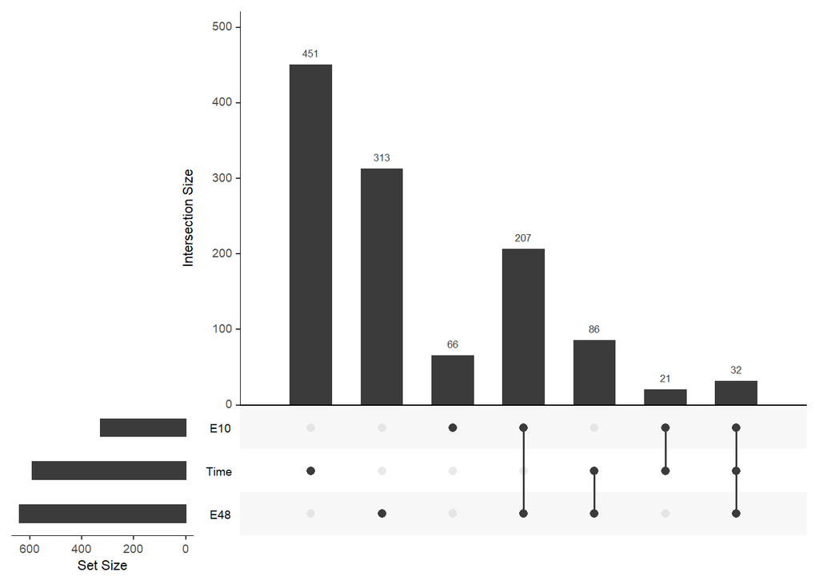

```r
#summarize the results
dt <- (decideTests(fitC) != 0)+0

#Create Venn diagrams
upset(as.data.frame(dt))
```

## Question 2.

Using the estrogen dataset from Exercise 5, reproduce the (limma) differential expression analysis using a different design matrix (remember, it’s all about the combination of a design matrix and a contrast matrix). Hint: use the experimental factors defined in the ‘targets’ data frame.

```r
# Get design matrix
(dm2 <- model.matrix( ~ estrogen*time.h, data=targets ))
```

```
  (Intercept) estrogenpresent time.h48 estrogenpresent:time.h48
1           1               0        0                        0
2           1               0        0                        0
3           1               1        0                        0
4           1               1        0                        0
5           1               0        1                        0
6           1               0        1                        0
7           1               1        1                        1
8           1               1        1                        1
attr(,"assign")
[1] 0 1 2 3
attr(,"contrasts")
attr(,"contrasts")$estrogen
[1] "contr.treatment"

attr(,"contrasts")$time.h
[1] "contr.treatment"
```

```r
fit2 <- lmFit(eset, dm2)
fit2  <- eBayes(fit2)
```

```r
topTable(fit2, coef=3, n=5)
```

```
                    logFC   AveExpr         t      P.Value    adj.P.Val
AFFX-CreX-5_at  -6.826151  9.921026 -32.81011 3.108614e-10 2.703546e-06
AFFX-CreX-3_at  -6.526324 10.406343 -31.58459 4.282844e-10 2.703546e-06
AFFX-BioDn-5_at -3.734781  8.348424 -19.15515 2.815350e-08 1.184793e-04
AFFX-BioB-M_at  -3.408360  8.270105 -18.28381 4.143024e-08 1.307642e-04
AFFX-BioDn-3_at -2.485797 11.401080 -15.52522 1.598695e-07 4.036706e-04
                        B
AFFX-CreX-5_at  10.655112
AFFX-CreX-3_at  10.547986
AFFX-BioDn-5_at  8.575319
AFFX-BioB-M_at   8.336458
AFFX-BioDn-3_at  7.427475
```

## Question 3.

Fix the code above to work on the count table that was already read in. Add in some spot checks, including an MDS plot from plotMDS() (or similar), a look at the dispersion-mean plot using plotBCV() (or similar) and a look at the overall M vs A plot using plotSmear() (or similar).

```r
(samples <- read.table("samples.txt", header=TRUE,
                      row.names=5, stringsAsFactors=FALSE))
```

```
                  rep condition libtype shortname           countfile
CG8144_RNAi-1.bam  T1         T      SE     T1.SE CG8144_RNAi-1.count
CG8144_RNAi-3.bam  T3         T      PE     T3.PE CG8144_RNAi-3.count
CG8144_RNAi-4.bam  T4         T      PE     T4.PE CG8144_RNAi-4.count
Untreated-1.bam    C1         C      SE     C1.SE   Untreated-1.count
Untreated-6.bam    C6         C      SE     C6.SE   Untreated-6.count
Untreated-3.bam    C3         C      PE     C3.PE   Untreated-3.count
Untreated-4.bam    C4         C      PE     C4.PE   Untreated-4.count
```

```r
counts <- readDGE(samples$countfile)$counts
(grp <- gsub("\\-.[0-9]*","",colnames(counts)))
```

```
[1] "CG8144_RNAi" "CG8144_RNAi" "CG8144_RNAi" "Untreated"   "Untreated"
[6] "Untreated"   "Untreated"
```

```r
y <- DGEList(counts=counts,group=grp)
y <- calcNormFactors(y)
design <- model.matrix(~grp)

y <- estimateDisp(y,design)

#To perform likelihood ratio tests:
fit <- glmFit(y,design)
lrt <- glmLRT(fit,coef=2)
topTags(lrt)
```

```
Coefficient:  grpUntreated
                logFC   logCPM       LR        PValue           FDR
FBgn0039155  4.612728 5.713330 560.3984 6.885924e-124 1.048451e-119
FBgn0039827  4.026942 4.244841 301.4369  1.602220e-67  1.219770e-63
FBgn0025111 -2.932831 6.716692 292.5665  1.372001e-65  6.963361e-62
FBgn0034736  3.533232 3.987363 222.2421  2.933166e-50  1.116510e-46
FBgn0003360  3.168704 8.269281 219.2281  1.332778e-49  4.058576e-46
FBgn0035085  2.525586 5.429273 206.6463  7.405792e-47  1.879343e-43
FBgn0000071 -2.715199 4.578686 193.1763  6.442282e-44  1.401288e-40
FBgn0029167  2.200346 8.025632 190.2500  2.803829e-43  5.336388e-40
FBgn0029896  2.410059 5.092969 174.8458  6.469506e-40  1.094497e-36
FBgn0034434  3.532031 3.007545 169.2943  1.055100e-38  1.606496e-35
```

```r
#MDS plot
plotMDS(y)
```

[output not shown]

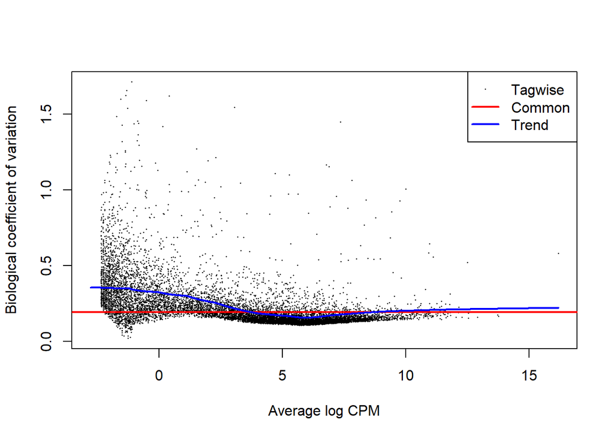

```r
#dispersion-mean plot
plotBCV(y)
```

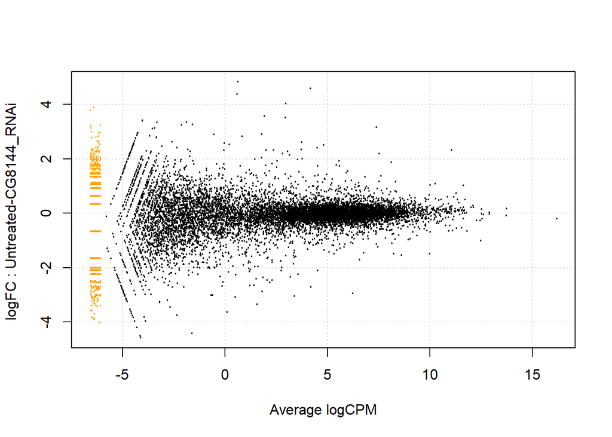

```r
#overall M vs A plot
plotSmear(y)
```

## Question 4.

For the MDS plot, investigate what happens differently when you call plotMDS() on the DGEList object and when you call it on the normalized counts – for normalized counts, see the cpm() function. Explain why it is different.

```r
#MDS Plot on DGEList object
plotMDS(y)
```

[figure not shown]

```r
#MDS Plot on normalized counts
plotMDS(cpm(y))
```

[output not shown]

Calling plotMDS() on a DGEList will call cpm() only after adding prior.count=2 and then create an MDS plot on the log-CPMs generated from the count matrix. We cam make the plot look the same as the MDS Plot on DGEList object by calling cpm() with log=TRUE and prior.count=2. Since prior.count=2 is the default for this version we can simply do this:

```r
#MDS Plot that looks the same as MDS Plot on DGEList object
plotMDS(cpm(y, log=TRUE))
```

[output not shown]

## Question 5.

Again, the above code for voom is not run here. Fix this code to work with the count dataset above and then do some spot checks of the genes called DE. For example, make a plot of the plot of estimated fold changes for the two methods (limma and edgeR), compare the P-values of the two methods, or create a venn diagram of the called sets of DE genes at a set threshold.

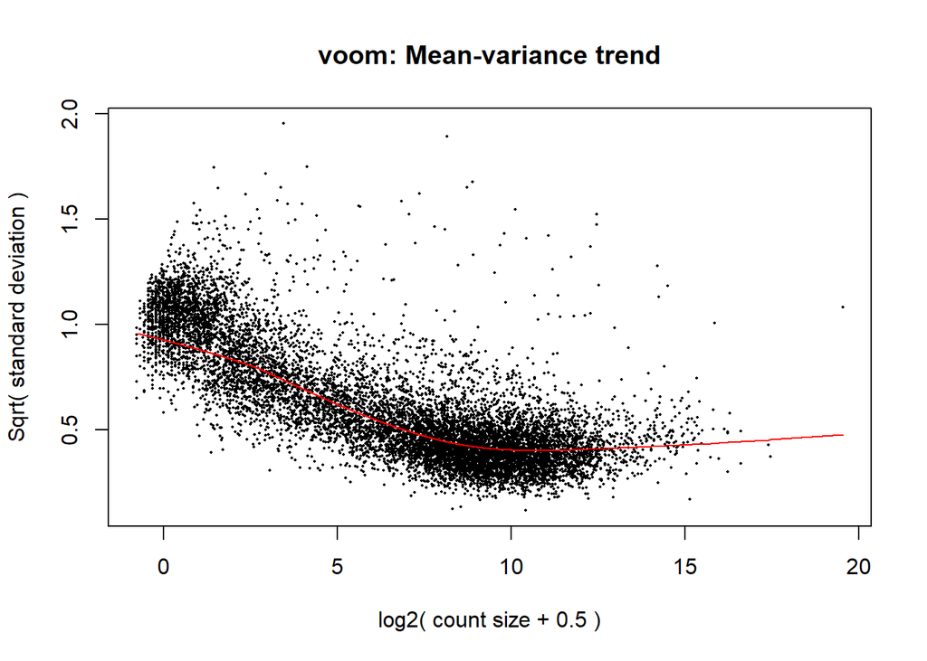

```r
#voom
v <- voom(y, design=model.matrix(~grp), plot = TRUE)
```

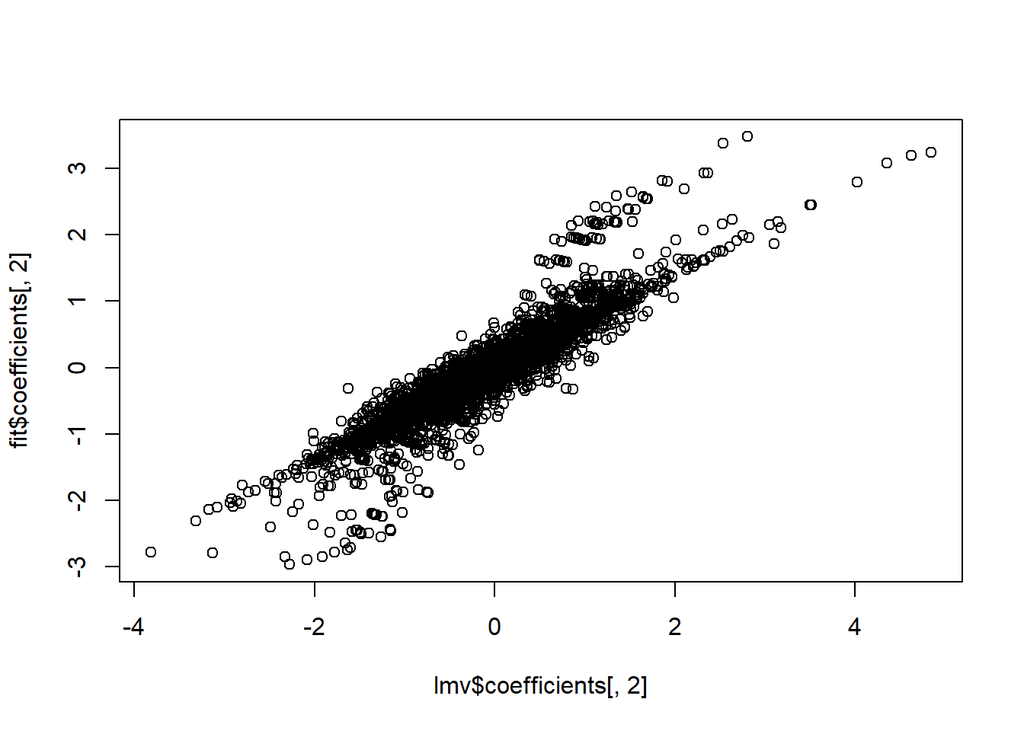

```r
#plot of the plot of estimated fold changes for the two methods

lmv= lmFit(v, design = model.matrix(~grp))
lmv = eBayes(lmv)

plot(lmv$coefficients[,2], fit$coefficients[,2]);
```

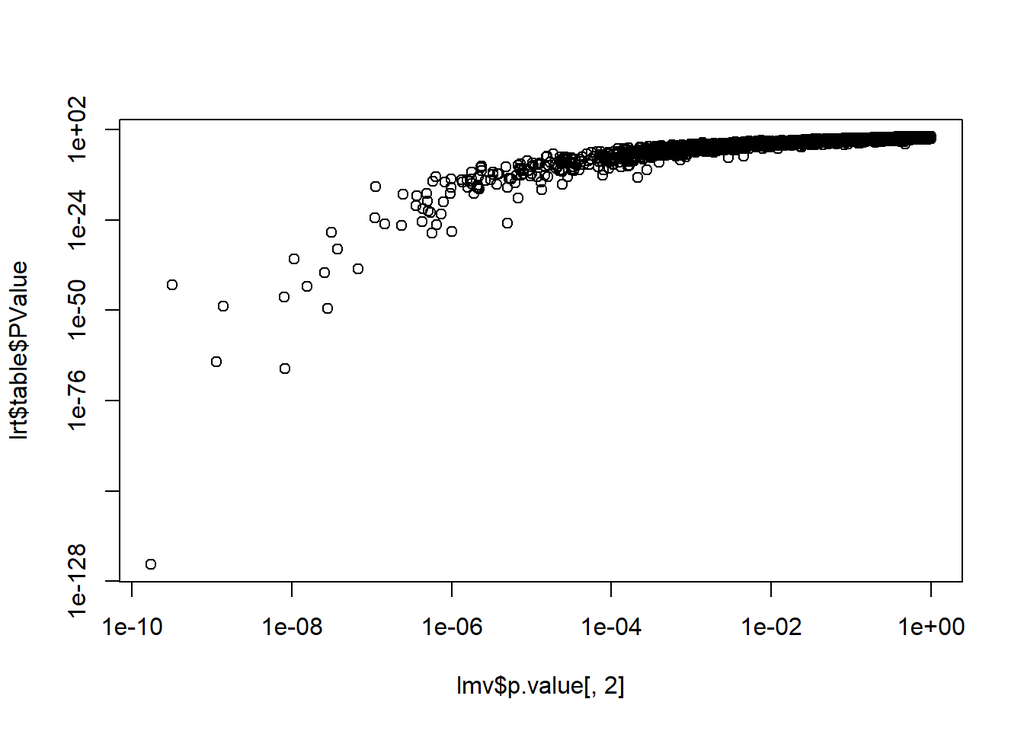

```r
#Compare the P-values of the two methods
plot(lmv$p.value[,2], lrt$table$PValue,log="xy");
```